# Risk Factor Analysis

## Outcome Variable

**Outcome Variable:** haz

## Predictor Variables

**Intervention Variable:** country

**Adjustment Set:**

unadjusted

## Stratifying Variables

The analysis was stratified on these variable(s):

- agecat

## Data Summary

| agecat | country | n_cell | n |
| --- | --- | --- | --- |
| Birth | BANGLADESH | 20760 | 62600 |
| Birth | BELARUS | 13884 | 62600 |
| Birth | BRAZIL | 306 | 62600 |
| Birth | GAMBIA | 1541 | 62600 |
| Birth | GUATEMALA | 852 | 62600 |
| Birth | GUINEA-BISSAU | 0 | 62600 |
| Birth | INDIA | 7511 | 62600 |
| Birth | MALAWI | 0 | 62600 |
| Birth | NEPAL | 173 | 62600 |
| Birth | PAKISTAN | 9 | 62600 |
| Birth | PERU | 299 | 62600 |
| Birth | PHILIPPINES | 3050 | 62600 |
| Birth | SOUTH AFRICA | 262 | 62600 |
| Birth | TANZANIA, UNITED REPUBLIC OF | 123 | 62600 |
| Birth | ZIMBABWE | 13830 | 62600 |
| 6 months | BANGLADESH | 23961 | 70727 |
| 6 months | BELARUS | 15761 | 70727 |
| 6 months | BRAZIL | 317 | 70727 |
| 6 months | GAMBIA | 2089 | 70727 |
| 6 months | GUATEMALA | 1260 | 70727 |
| 6 months | GUINEA-BISSAU | 848 | 70727 |
| 6 months | INDIA | 9588 | 70727 |
| 6 months | MALAWI | 839 | 70727 |
| 6 months | NEPAL | 799 | 70727 |
| 6 months | PAKISTAN | 607 | 70727 |
| 6 months | PERU | 1125 | 70727 |
| 6 months | PHILIPPINES | 2708 | 70727 |
| 6 months | SOUTH AFRICA | 254 | 70727 |
| 6 months | TANZANIA, UNITED REPUBLIC OF | 2276 | 70727 |
| 6 months | ZIMBABWE | 8295 | 70727 |
| 24 months | BANGLADESH | 15358 | 34719 |
| 24 months | BELARUS | 4035 | 34719 |
| 24 months | BRAZIL | 169 | 34719 |
| 24 months | GAMBIA | 1725 | 34719 |
| 24 months | GUATEMALA | 1073 | 34719 |
| 24 months | GUINEA-BISSAU | 551 | 34719 |
| 24 months | INDIA | 6348 | 34719 |
| 24 months | MALAWI | 579 | 34719 |
| 24 months | NEPAL | 727 | 34719 |
| 24 months | PAKISTAN | 0 | 34719 |
| 24 months | PERU | 794 | 34719 |
| 24 months | PHILIPPINES | 2445 | 34719 |
| 24 months | SOUTH AFRICA | 238 | 34719 |
| 24 months | TANZANIA, UNITED REPUBLIC OF | 220 | 34719 |
| 24 months | ZIMBABWE | 457 | 34719 |

The following strata were considered:

- agecat: 24 months
- agecat: 6 months
- agecat: Birth

### Dropped Strata

Some strata were dropped due to rare outcomes:

- agecat: Birth
- agecat: 24 months

## Methods Detail

We’re interested in the causal parameters $E[Y_a]$ for all values of $a \in \mathcal{A}$. These parameters represent the mean outcome if, possibly contrary to fact, we intervened to set all units to have $A=a$. Under the randomization and positivity assumptions, these are identified by the statistical parameters $\psi_a=E_W[E_{Y|A,W}(Y|A=a,W)]$. In addition, we’re interested in the mean of $Y$, $E[Y]$ under no intervention (the observed mean). We will estimate these parameters by using SuperLearner to fit the relevant likelihood factors – $E_{Y|A,W}(Y|A=a,W)$ and $p(A=a|W)$, and then updating our likelihood fit using a joint TMLE.

For unadjusted analyses ($W=\{\}$), initial likelihoods were estimated using Lrnr_glm to estimate the simple $E(Y|A)$ and Lrnr_mean to estimate $p(A)$. For adjusted analyses, a small library containing Lrnr_glmnet, Lrnr_xgboost, and Lrnr_mean was used.

Having estimated these parameters, we will then use the delta method to estimate relative risks and attributable risks relative to a prespecified baseline level of $A$.

# Results Detail

## Results Plots

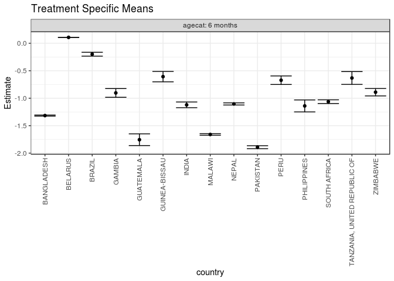

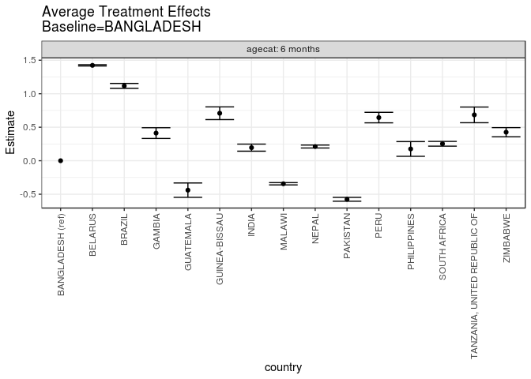

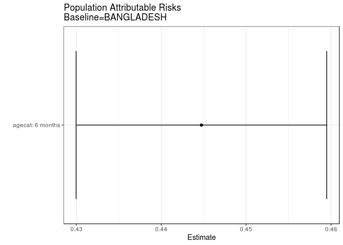

## Results Table

### Parameter: TSM

| agecat | intervention_level | baseline_level | estimate | ci_lower | ci_upper |
| --- | --- | --- | --- | --- | --- |
| 6 months | BANGLADESH | NA | -1.3163849 | -1.3259482 | -1.3068215 |
| 6 months | BELARUS | NA | 0.1069986 | 0.1065857 | 0.1074115 |
| 6 months | BRAZIL | NA | -0.1994532 | -0.2346574 | -0.1642490 |
| 6 months | GAMBIA | NA | -0.9041369 | -0.9836906 | -0.8245832 |
| 6 months | GUATEMALA | NA | -1.7554987 | -1.8622450 | -1.6487524 |
| 6 months | GUINEA-BISSAU | NA | -0.6075943 | -0.7020405 | -0.5131482 |
| 6 months | INDIA | NA | -1.1210266 | -1.1730546 | -1.0689987 |
| 6 months | MALAWI | NA | -1.6601907 | -1.6742692 | -1.6461122 |
| 6 months | NEPAL | NA | -1.1043951 | -1.1241370 | -1.0846531 |
| 6 months | PAKISTAN | NA | -1.8916996 | -1.9187439 | -1.8646553 |
| 6 months | PERU | NA | -0.6725806 | -0.7503328 | -0.5948284 |
| 6 months | PHILIPPINES | NA | -1.1405724 | -1.2497657 | -1.0313791 |
| 6 months | SOUTH AFRICA | NA | -1.0633760 | -1.0972662 | -1.0294858 |
| 6 months | TANZANIA, UNITED REPUBLIC OF | NA | -0.6320683 | -0.7486452 | -0.5154914 |
| 6 months | ZIMBABWE | NA | -0.8907480 | -0.9582906 | -0.8232055 |

### Parameter: E(Y)

| agecat | intervention_level | baseline_level | estimate | ci_lower | ci_upper |
| --- | --- | --- | --- | --- | --- |
| 6 months | NA | NA | -0.8716525 | -0.8853712 | -0.8579339 |

### Parameter: ATE

| agecat | intervention_level | baseline_level | estimate | ci_lower | ci_upper |
| --- | --- | --- | --- | --- | --- |
| 6 months | BANGLADESH | BANGLADESH | 0.0000000 | 0.0000000 | 0.0000000 |
| 6 months | BELARUS | BANGLADESH | 1.4233835 | 1.4138111 | 1.4329558 |
| 6 months | BRAZIL | BANGLADESH | 1.1169316 | 1.0804496 | 1.1534137 |
| 6 months | GAMBIA | BANGLADESH | 0.4122479 | 0.3321223 | 0.4923735 |
| 6 months | GUATEMALA | BANGLADESH | -0.4391138 | -0.5462738 | -0.3319538 |
| 6 months | GUINEA-BISSAU | BANGLADESH | 0.7087905 | 0.6138613 | 0.8037197 |
| 6 months | INDIA | BANGLADESH | 0.1953582 | 0.1424551 | 0.2482614 |
| 6 months | MALAWI | BANGLADESH | -0.3438058 | -0.3608266 | -0.3267851 |
| 6 months | NEPAL | BANGLADESH | 0.2119898 | 0.1900550 | 0.2339245 |
| 6 months | PAKISTAN | BANGLADESH | -0.5753148 | -0.6040089 | -0.5466207 |
| 6 months | PERU | BANGLADESH | 0.6438043 | 0.5654650 | 0.7221435 |
| 6 months | PHILIPPINES | BANGLADESH | 0.1758125 | 0.0662012 | 0.2854238 |
| 6 months | SOUTH AFRICA | BANGLADESH | 0.2530089 | 0.2178038 | 0.2882139 |
| 6 months | TANZANIA, UNITED REPUBLIC OF | BANGLADESH | 0.6843165 | 0.5673365 | 0.8012966 |
| 6 months | ZIMBABWE | BANGLADESH | 0.4256368 | 0.3574223 | 0.4938513 |

### Parameter: PAR

| agecat | intervention_level | baseline_level | estimate | ci_lower | ci_upper |
| --- | --- | --- | --- | --- | --- |
| 6 months | BANGLADESH | NA | 0.4447323 | 0.4299694 | 0.4594952 |